# Weather and Corn Yield Regressions

Alex Siggers

03/04/2022

## Assignment

### Question 1a: Extract Winneshiek County corn yields, fit a linear time trend, make a plot. Is there a significant time trend?

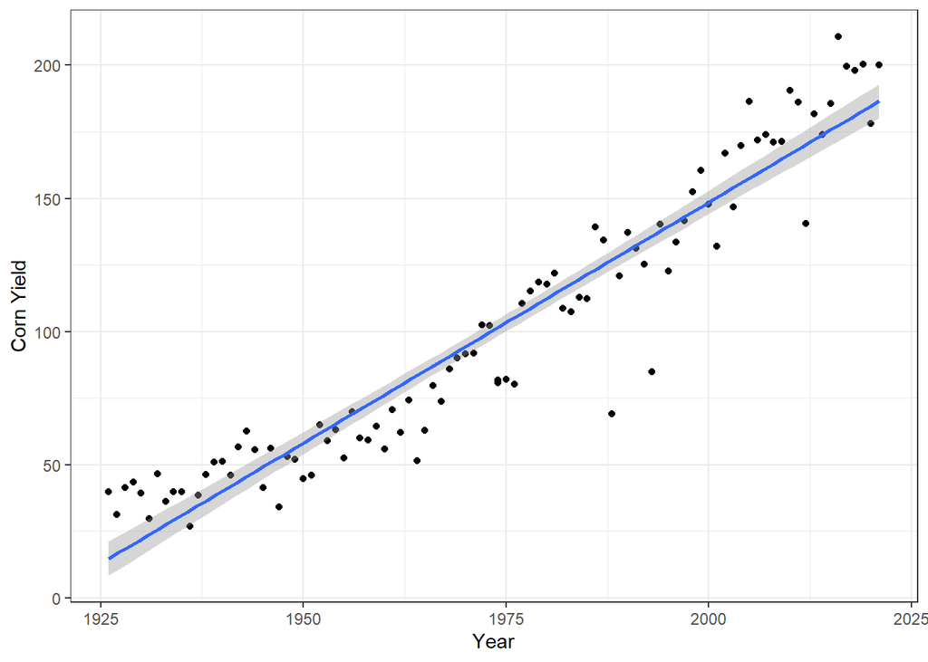

```r
#1a
WinneshiekCorn <- cornyields %>%
  filter(county_name == "WINNESHIEK")

ggplot(WinneshiekCorn, mapping = aes(x = year, y = yield)) +
  geom_point() +
  theme_bw() +
  labs(x = "Year", y = "Corn Yield") +
  geom_smooth(method = lm)
```

```r
WinCornLm <- lm(yield ~ year, WinneshiekCorn)
summary(WinCornLm)
```

```
##
## Call:
## lm(formula = yield ~ year, data = WinneshiekCorn)
##
## Residuals:
##     Min      1Q  Median      3Q     Max
## -57.767  -7.775   2.365  10.508  33.187
##
## Coefficients:
##               Estimate Std. Error t value Pr(>|t|)
## (Intercept) -3469.0208   115.4526  -30.05   <2e-16 ***
## year            1.8088     0.0585   30.92   <2e-16 ***
## ---
## Signif. codes:  0 '***' 0.001 '**' 0.01 '*' 0.05 '.' 0.1 ' ' 1
##
## Residual standard error: 15.88 on 95 degrees of freedom
## Multiple R-squared:  0.9096, Adjusted R-squared:  0.9087
## F-statistic: 956.2 on 1 and 95 DF,  p-value: < 2.2e-16
```

-##There is a very significant linear increase in corn yield with year. The linear model provides evidence, and the scatterplot visualizes the trend. ##

### Question 1b: Fit a quadratic time trend (i.e., year + year^2) and make a plot. Is there evidence for slowing yield growth?

```r
#1b
WinneshiekCorn$yearsq <- WinneshiekCorn$year^2

lm_wincornquad <- lm(yield ~ year + yearsq, WinneshiekCorn)
summary(lm_wincornquad)
```

```
##
## Call:
## lm(formula = yield ~ year + yearsq, data = WinneshiekCorn)
##
## Residuals:
##     Min      1Q  Median      3Q     Max
## -50.608  -5.847   1.074   7.135  25.757
##
## Coefficients:
##               Estimate Std. Error t value Pr(>|t|)
## (Intercept)  4.725e+04  7.546e+03   6.261 1.13e-08 ***
## year        -4.960e+01  7.648e+00  -6.485 4.10e-09 ***
## yearsq       1.302e-02  1.938e-03   6.721 1.38e-09 ***
## ---
## Signif. codes:  0 '***' 0.001 '**' 0.01 '*' 0.05 '.' 0.1 ' ' 1
##
## Residual standard error: 13.12 on 94 degrees of freedom
## Multiple R-squared:  0.939,  Adjusted R-squared:  0.9377
## F-statistic:   723 on 2 and 94 DF,  p-value: < 2.2e-16
```

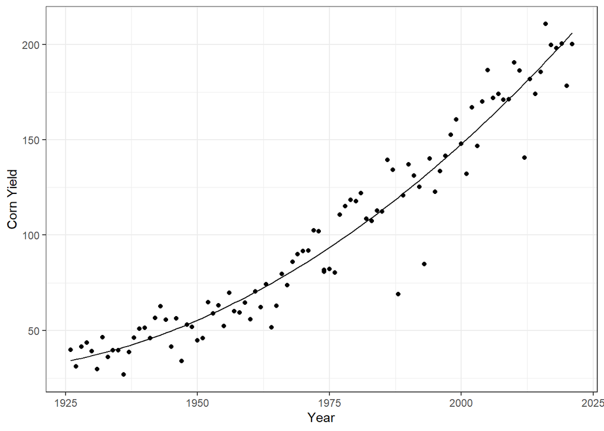

```r
WinneshiekCorn$fitted <- lm_wincornquad$fitted.values

ggplot(WinneshiekCorn) +
  geom_point(mapping = aes(x = year, y = yield)) +
  geom_line(mapping = aes(x = year, y = fitted)) +
  theme_bw() +
  labs(x = "Year", y = "Corn Yield")
```

-##The evidence seems to suggest that the corn yield is only growing, seemingly exponentially under the quadratic fit. ##

### Question 2 – Time Series: Let’s analyze the relationship between temperature and yields for the Winneshiek County time series. Use data on yield and summer avg Tmax. Is adding year or Tmax^2 to your model helpful? Make a plot and interpret the results.

```r
WinTime = merge(WinneshiekCorn, winnesummer, by="year")

YieldTemplm=lm(yield~meantmax, WinTime)
summary(YieldTemplm)
```

```
##
## Call:
## lm(formula = yield ~ meantmax, data = WinTime)
##
## Residuals:
##    Min     1Q Median     3Q    Max
## -71.96 -19.85  -3.19  24.64  61.72
##
## Coefficients:
##             Estimate Std. Error t value Pr(>|t|)
## (Intercept)  275.876    118.335   2.331   0.0255 *
## meantmax      -4.763      4.438  -1.073   0.2902
## ---
## Signif. codes:  0 '***' 0.001 '**' 0.01 '*' 0.05 '.' 0.1 ' ' 1
##
## Residual standard error: 32.88 on 36 degrees of freedom
## Multiple R-squared:  0.03101,    Adjusted R-squared:  0.004098
## F-statistic: 1.152 on 1 and 36 DF,  p-value: 0.2902
```

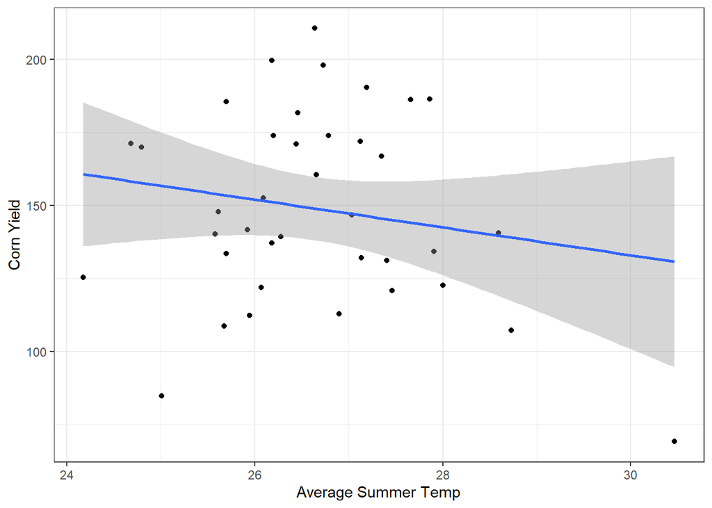

```r
ggplot(WinTime, mapping = aes(x = meantmax, y = yield)) +
  geom_point() +
  theme_bw() +
  labs(x = "Average Summer Temp", y = "Corn Yield") +
  geom_smooth(method = lm)
```

### Question 3 – Cross-Section: Analyze the relationship between temperature and yield across all counties in 2018. Is there a relationship? Interpret the results.

```r
#Q3
rename(tmaxdf, "county_ansi" = "countyfp")
```

```
## # A tibble: 1,376,892 x 4
##    county_ansi   doy  year   tmax
##    <fct>       <dbl> <dbl>  <dbl>
##  1 93              1  1981 4.31
##  2 147             1  1981 1.88
##  3 13              1  1981 1.03
##  4 99              1  1981 3.99
##  5 195             1  1981 0.0337
##  6 67              1  1981 0.530
##  7 107             1  1981 4.24
##  8 15              1  1981 3.98
##  9 57              1  1981 2.52
## 10 127             1  1981 1.64
## # ... with 1,376,882 more rows
```

```r
names(tmaxdf)[names(tmaxdf)=="countyfp"] <- "county_ansi"

TempData2018 <- tmaxdf %>%
  filter(doy >= 152 & doy <= 243) %>%
  filter(year == "2018") %>%
  group_by(county_ansi)

Data2018 <- cornyields %>%
  filter(year == "2018")

TD2018 <- merge(TempData2018, Data2018, by="county_ansi")



lm2018 <- lm(yield~tmax, TD2018)
summary(lm2018)
```

```
##
## Call:
## lm(formula = yield ~ tmax, data = TD2018)
##
## Residuals:
##     Min      1Q  Median      3Q     Max
## -45.711 -13.558   0.488  17.677  34.474
##
## Coefficients:
##             Estimate Std. Error t value Pr(>|t|)
## (Intercept) 202.6112     1.8754 108.035  < 2e-16 ***
## tmax         -0.3309     0.0659  -5.022 5.23e-07 ***
## ---
## Signif. codes:  0 '***' 0.001 '**' 0.01 '*' 0.05 '.' 0.1 ' ' 1
##
## Residual standard error: 19.77 on 8554 degrees of freedom
## Multiple R-squared:  0.002939,   Adjusted R-squared:  0.002823
## F-statistic: 25.22 on 1 and 8554 DF,  p-value: 5.226e-07
```

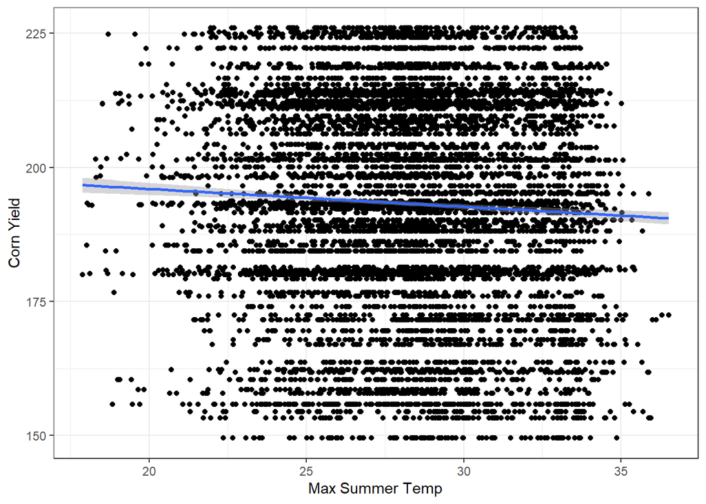

```r
ggplot(TD2018, mapping = aes(x = tmax, y = yield)) +
  geom_point() +
  theme_bw() +
  labs(x = "Max Summer Temp", y = "Corn Yield") +
  geom_smooth(method = lm)
```

### Question 4 – Panel: One way to leverage multiple time series is to group all data into what is called a “panel” regression. Convert the county ID code (“countyfp” or “county_ansi”) into factor using as.factor, then include this variable in a regression using all counties’ yield and summer temperature data. How does the significance of your temperature coefficients (Tmax, Tmax^2) change? Make a plot comparing actual and fitted yields and interpret the results of your model.

```r
library(gridExtra)
#Q4
#Converting to factors
cornyields$county_ansi=as.factor(cornyields$county_ansi)
cornyields$county_name=as.factor(cornyields$county_name)
tmaxdf$county_ansi=as.factor(tmaxdf$county_ansi)

#Creating tmax and tmax^2 df
MaxTemps <- tmaxdf %>%
  filter(doy >= 152 & doy <= 243) %>%
  group_by(year, county_ansi) %>%
  summarize(meantmax = mean(tmax))

MaxTemps$county_ansi=as.factor(MaxTemps$county_ansi)

#Creating master df
MaxTempYield = merge(MaxTemps, cornyields) %>%
  mutate(yearsq=year^2,
         yieldsq=yield^2,
         tmaxsq=meantmax^2)

#Creating models for each factor
tempquadr = lm(yield~meantmax + tmaxsq, MaxTempYield)
summary(tempquadr)
```

```
##
## Call:
## lm(formula = yield ~ meantmax + tmaxsq, data = MaxTempYield)
##
## Residuals:
##      Min       1Q   Median       3Q      Max
## -113.151  -21.982   -2.794   24.860   82.006
##
## Coefficients:
##               Estimate Std. Error t value Pr(>|t|)
## (Intercept) -2098.6219   139.4315  -15.05   <2e-16 ***
## meantmax      168.9590     9.9402   17.00   <2e-16 ***
## tmaxsq         -3.1665     0.1769  -17.90   <2e-16 ***
## ---
## Signif. codes:  0 '***' 0.001 '**' 0.01 '*' 0.05 '.' 0.1 ' ' 1
##
## Residual standard error: 31.55 on 3745 degrees of freedom
## Multiple R-squared:  0.1947, Adjusted R-squared:  0.1943
## F-statistic: 452.8 on 2 and 3745 DF,  p-value: < 2.2e-16
```

```r
MaxTempYield$tempsqfit <- tempquadr$fitted.values

yearlm = lm(yield~year, MaxTempYield)
summary(yearlm)
```

```
##
## Call:
## lm(formula = yield ~ year, data = MaxTempYield)
##
## Residuals:
##     Min      1Q  Median      3Q     Max
## -128.90  -10.56    4.87   16.68   45.17
##
## Coefficients:
##               Estimate Std. Error t value Pr(>|t|)
## (Intercept) -4.508e+03  7.244e+01  -62.23   <2e-16 ***
## year         2.327e+00  3.623e-02   64.22   <2e-16 ***
## ---
## Signif. codes:  0 '***' 0.001 '**' 0.01 '*' 0.05 '.' 0.1 ' ' 1
##
## Residual standard error: 24.25 on 3746 degrees of freedom
## Multiple R-squared:  0.5241, Adjusted R-squared:  0.5239
## F-statistic:  4125 on 1 and 3746 DF,  p-value: < 2.2e-16
```

```r
MaxTempYield$yearfit <- yearlm$fitted.values

countylm = lm(yield~county_name, MaxTempYield)
summary(countylm)
```

```
##
## Call:
## lm(formula = yield ~ county_name, data = MaxTempYield)
##
## Residuals:
##      Min       1Q   Median       3Q      Max
## -113.903  -20.766   -0.897   24.376   78.450
##
## Coefficients:
##                          Estimate Std. Error t value Pr(>|t|)
## (Intercept)               136.076      5.450  24.967  < 2e-16 ***
## county_nameADAMS           -4.363      7.708  -0.566  0.57138
## county_nameALLAMAKEE       10.879      7.708   1.411  0.15821
## county_nameAPPANOOSE      -20.117      7.760  -2.592  0.00957 **
## county_nameAUDUBON          8.829      7.708   1.145  0.25210
## county_nameBENTON          12.461      7.708   1.617  0.10605
## county_nameBLACK HAWK      14.071      7.708   1.826  0.06800 .
## county_nameBOONE           18.439      7.708   2.392  0.01679 *
## county_nameBREMER          18.711      7.708   2.427  0.01525 *
## county_nameBUCHANAN        15.166      7.708   1.968  0.04919 *
## county_nameBUENA VISTA     15.182      7.708   1.970  0.04896 *
## county_nameBUTLER          15.437      7.708   2.003  0.04528 *
## county_nameCALHOUN         16.118      7.708   2.091  0.03658 *
## county_nameCARROLL         13.984      7.708   1.814  0.06972 .
## county_nameCASS             6.453      7.708   0.837  0.40256
## county_nameCEDAR           20.400      7.708   2.647  0.00816 **
## county_nameCERRO GORDO     12.395      7.708   1.608  0.10791
## county_nameCHEROKEE        19.350      7.708   2.510  0.01210 *
## county_nameCHICKASAW       10.234      7.708   1.328  0.18434
## county_nameCLARKE         -25.360      7.760  -3.268  0.00109 **
## county_nameCLAY            13.413      7.708   1.740  0.08191 .
## county_nameCLAYTON         16.545      7.708   2.146  0.03190 *
## county_nameCLINTON         15.534      7.708   2.015  0.04394 *
## county_nameCRAWFORD        11.332      7.708   1.470  0.14161
## county_nameDALLAS          11.895      7.708   1.543  0.12287
## county_nameDAVIS          -19.690      7.760  -2.537  0.01121 *
## county_nameDECATUR        -18.293      7.760  -2.357  0.01846 *
## county_nameDELAWARE        17.039      7.708   2.211  0.02712 *
## county_nameDES MOINES       9.116      7.708   1.183  0.23702
## county_nameDICKINSON       10.329      7.708   1.340  0.18031
```

[output cut: 60 more lines]

```
## county_nameWARREN          -2.482      7.708  -0.322  0.74751
## county_nameWASHINGTON       8.547      7.708   1.109  0.26754
## county_nameWAYNE          -22.703      7.760  -2.926  0.00346 **
## county_nameWEBSTER         20.197      7.708   2.620  0.00882 **
## county_nameWINNEBAGO       16.334      7.708   2.119  0.03414 *
## county_nameWINNESHIEK      12.905      7.708   1.674  0.09416 .
## county_nameWOODBURY         4.774      7.708   0.619  0.53574
## county_nameWORTH           14.189      7.708   1.841  0.06572 .
## county_nameWRIGHT          18.379      7.708   2.384  0.01716 *
## ---
## Signif. codes:  0 '***' 0.001 '**' 0.01 '*' 0.05 '.' 0.1 ' ' 1
##
## Residual standard error: 33.6 on 3649 degrees of freedom
## Multiple R-squared:  0.1104, Adjusted R-squared:  0.08648
## F-statistic:  4.62 on 98 and 3649 DF,  p-value: < 2.2e-16
```

```r
MaxTempYield$countyfit <- countylm$fitted.values

allquadr = lm(yield ~ year + meantmax + tmaxsq + county_name, MaxTempYield)
summary(allquadr)
```

```
##
## Call:
## lm(formula = yield ~ year + meantmax + tmaxsq + county_name,
##     data = MaxTempYield)
##
## Residuals:
##     Min      1Q  Median      3Q     Max
## -81.645  -9.720   1.924  13.232  40.409
##
## Coefficients:
##                            Estimate Std. Error t value Pr(>|t|)
## (Intercept)              -5.826e+03  9.804e+01 -59.431  < 2e-16 ***
## year                      2.203e+00  2.836e-02  77.664  < 2e-16 ***
## meantmax                  1.182e+02  6.108e+00  19.352  < 2e-16 ***
## tmaxsq                   -2.225e+00  1.085e-01 -20.503  < 2e-16 ***
## county_nameADAMS         -4.527e+00  4.321e+00  -1.048 0.294839
## county_nameALLAMAKEE      2.716e+00  4.343e+00   0.625 0.531743
## county_nameAPPANOOSE     -1.828e+01  4.350e+00  -4.203 2.70e-05 ***
## county_nameAUDUBON        5.068e+00  4.323e+00   1.172 0.241144
## county_nameBENTON         7.186e+00  4.325e+00   1.661 0.096732 .
## county_nameBLACK HAWK     7.289e+00  4.329e+00   1.684 0.092303 .
## county_nameBOONE          1.498e+01  4.323e+00   3.466 0.000534 ***
## county_nameBREMER         1.133e+01  4.332e+00   2.615 0.008966 **
## county_nameBUCHANAN       7.651e+00  4.334e+00   1.765 0.077577 .
## county_nameBUENA VISTA    8.640e+00  4.328e+00   1.996 0.045974 *
## county_nameBUTLER         9.089e+00  4.327e+00   2.100 0.035779 *
## county_nameCALHOUN        1.039e+01  4.326e+00   2.401 0.016400 *
## county_nameCARROLL        9.666e+00  4.323e+00   2.236 0.025421 *
## county_nameCASS           6.145e+00  4.321e+00   1.422 0.155092
## county_nameCEDAR          1.579e+01  4.324e+00   3.651 0.000264 ***
## county_nameCERRO GORDO    4.582e+00  4.338e+00   1.056 0.290980
## county_nameCHEROKEE       1.390e+01  4.325e+00   3.213 0.001325 **
## county_nameCHICKASAW      2.169e+00  4.341e+00   0.500 0.617274
## county_nameCLARKE        -2.404e+01  4.350e+00  -5.527 3.48e-08 ***
## county_nameCLAY           6.611e+00  4.329e+00   1.527 0.126809
## county_nameCLAYTON        8.864e+00  4.337e+00   2.044 0.041033 *
## county_nameCLINTON        1.055e+01  4.325e+00   2.439 0.014756 *
## county_nameCRAWFORD       6.528e+00  4.324e+00   1.510 0.131221
## county_nameDALLAS         1.081e+01  4.321e+00   2.502 0.012386 *
## county_nameDAVIS         -1.457e+01  4.352e+00  -3.349 0.000820 ***
```

[output cut: 64 more lines]

```
## county_nameWARREN        -2.159e+00  4.321e+00  -0.500 0.617309
## county_nameWASHINGTON     1.042e+01  4.321e+00   2.410 0.015981 *
## county_nameWAYNE         -2.189e+01  4.350e+00  -5.033 5.07e-07 ***
## county_nameWEBSTER        1.421e+01  4.326e+00   3.285 0.001029 **
## county_nameWINNEBAGO      8.236e+00  4.344e+00   1.896 0.058035 .
## county_nameWINNESHIEK     4.567e+00  4.350e+00   1.050 0.293826
## county_nameWOODBURY       2.799e+00  4.321e+00   0.648 0.517252
## county_nameWORTH          6.123e+00  4.356e+00   1.406 0.159892
## county_nameWRIGHT         1.156e+01  4.329e+00   2.669 0.007634 **
## ---
## Signif. codes:  0 '***' 0.001 '**' 0.01 '*' 0.05 '.' 0.1 ' ' 1
##
## Residual standard error: 18.83 on 3646 degrees of freedom
## Multiple R-squared:  0.7207, Adjusted R-squared:  0.7129
## F-statistic: 93.13 on 101 and 3646 DF,  p-value: < 2.2e-16
```

```r
MaxTempYield$allfit <- allquadr$fitted.values

summary(MaxTempYield)
```

```
##       year       county_ansi      meantmax         county_name
##  Min.   :1981   93     :  38   Min.   :23.82   ADAIR     :  38
##  1st Qu.:1990   147    :  38   1st Qu.:26.97   ADAMS     :  38
##  Median :1999   13     :  38   Median :27.86   ALLAMAKEE :  38
##  Mean   :1999   99     :  38   Mean   :27.90   AUDUBON   :  38
##  3rd Qu.:2009   195    :  38   3rd Qu.:28.82   BENTON    :  38
##  Max.   :2018   67     :  38   Max.   :32.24   BLACK HAWK:  38
##                 (Other):3520                   (Other)   :3520
##      yield           yearsq           yieldsq            tmaxsq
##  Min.   : 19.1   Min.   :3924361   Min.   :  364.8   Min.   : 567.5
##  1st Qu.:123.2   1st Qu.:3960100   1st Qu.:15178.2   1st Qu.: 727.3
##  Median :143.6   Median :3996001   Median :20621.0   Median : 776.0
##  Mean   :144.2   Mean   :3997861   Mean   :22018.6   Mean   : 780.4
##  3rd Qu.:170.3   3rd Qu.:4036081   3rd Qu.:29010.6   3rd Qu.: 830.7
##  Max.   :226.0   Max.   :4072324   Max.   :51076.0   Max.   :1039.4
##
##    tempsqfit         yearfit        countyfit         allfit
##  Min.   : 57.32   Min.   :101.3   Min.   :110.7   Min.   : 35.87
##  1st Qu.:140.36   1st Qu.:122.2   1st Qu.:140.0   1st Qu.:123.79
##  Median :149.94   Median :143.2   Median :148.3   Median :146.33
##  Mean   :144.16   Mean   :144.2   Mean   :144.2   Mean   :144.16
##  3rd Qu.:153.89   3rd Qu.:166.4   3rd Qu.:152.6   3rd Qu.:165.86
##  Max.   :155.23   Max.   :187.4   Max.   :156.8   Max.   :199.65
##
```

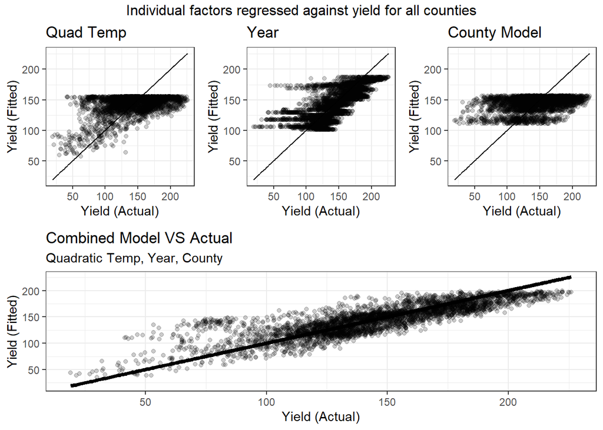

```r
#Creating visuals'
grid.arrange(
top = "Individual factors regressed against yield for all counties",
layout_matrix = rbind(c(1, 2, 3),c(4, 4, 4)),
ggplot(MaxTempYield) +
  geom_point(mapping = aes(x = yield, y = tempsqfit), alpha = 0.2) +
  geom_line(mapping = aes(x = yield, y = yield), linetype = "solid", size=0.5) +
  theme_bw() +
  labs(x = "Yield (Actual)", y = "Yield (Fitted)", title= "Quad Temp",)
,
ggplot(MaxTempYield) +
  geom_point(mapping = aes(x = yield, y = yearfit), alpha = 0.2) +
  geom_line(mapping = aes(x = yield, y = yield), linetype = "solid", size=0.5) +
  theme_bw() +
  labs(x = "Yield (Actual)", y = "Yield (Fitted)", title= "Year")
,
ggplot(MaxTempYield) +
  geom_point(mapping = aes(x = yield, y = countyfit), alpha = 0.2) +
  geom_line(mapping = aes(x = yield, y = yield), linetype = "solid", size=0.5) +
  theme_bw() +
  labs(x = "Yield (Actual)", y = "Yield (Fitted)", title= "County Model")
,
ggplot(MaxTempYield) +
  geom_point(mapping = aes(x = yield, y = allfit), alpha = 0.2) +
  geom_line(mapping = aes(x = yield, y = yield), linetype = "solid", size=1.5) +
  theme_bw() +
  labs(x = "Yield (Actual)", y = "Yield (Fitted)", title= "Combined Model VS Actual", subtitle="Quadratic Temp, Year, County")
)
```

-##The fit of years to yield (although not quadratic) provides the best fit to explain the correlation. The temperature and county models have very limited predictive power (though the temperature model is better than the county model). The combined model creates the best prediction visually. ##

### Question 5 – Soybeans: Download NASS data on soybean yields and explore either a time series relationship for a given county, the cross-sectional relationship for a given year, or a panel across all counties and years.

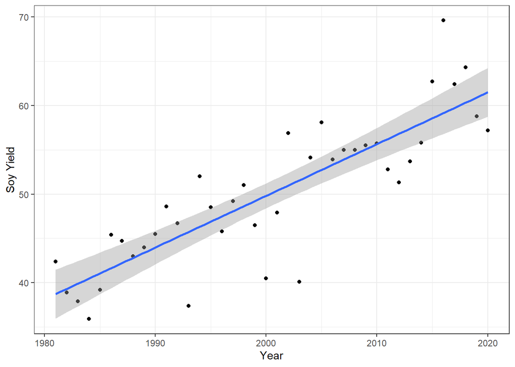

```r
soyyield$county_ansi <- as.numeric(soyyield$county_ansi)
soyyield$yield <- as.numeric(soyyield$Value)

# clean and filter this dataset
soyyields <- select(soyyield, county_ansi, county_name, yield, year) %>%
  filter(!is.na(county_ansi) & !is.na(yield))
soyyields <- tibble(soyyields)


#Subsetting a single county
CherokeeSoy <- soyyields %>%
  filter(county_name == "CHEROKEE")

ggplot(CherokeeSoy, mapping = aes(x = year, y = yield)) +
  geom_point() +
  theme_bw() +
  labs(x = "Year", y = "Soy Yield") +
  geom_smooth(method = lm)
```

```r
CherSoyLm <- lm(yield ~ year, CherokeeSoy)
summary(CherSoyLm)
```

```
##
## Call:
## lm(formula = yield ~ year, data = CherokeeSoy)
##
## Residuals:
##      Min       1Q   Median       3Q      Max
## -11.4563  -2.2537   0.5595   2.5287  10.4577
##
## Coefficients:
##               Estimate Std. Error t value Pr(>|t|)
## (Intercept) -1.117e+03  1.203e+02  -9.291 2.53e-11 ***
## year         5.835e-01  6.011e-02   9.707 7.74e-12 ***
## ---
## Signif. codes:  0 '***' 0.001 '**' 0.01 '*' 0.05 '.' 0.1 ' ' 1
##
## Residual standard error: 4.389 on 38 degrees of freedom
## Multiple R-squared:  0.7126, Adjusted R-squared:  0.7051
## F-statistic: 94.23 on 1 and 38 DF,  p-value: 7.743e-12
```

-There is a very evident positive correlation between time and soy yield in Cherokee county, which is supported by the linear model as well.

### Bonus: Find a package to make a county map of Iowa displaying some sort of information about yields or weather. Interpret your map.

### Bonus #2: Challenge question - map trends in corn yields by county across Iowa. Interpret your map.